# Outlier and Venn Diagram Results from Pinus contorta at different cutoffs for TASSEL

Katie Lotterhos

May 26, 2015

Data used here is stored on hulk at /data/seqcap/pine/bwa_pseudo/round2_bams/var_out_GATK3_allhet_pine688_ALL.summary.ALL.annots.sorted.GOOD.window_RESULTS. It was transferred to my laptop to make the markdown files

### The SNP dataset

Here are the column names in the SNP dataset: (the ones named after the environments contain Bayes Factors. “rho” represents Spearman’s rho, which indicates the correlation between the reference SNP frequency and the environment.)

```r
#filename <- "var_out_GATK3_allhet_pine688_ALL.summary.ALL.annots.sorted.GOOD.window.3xbf.log10"
filename <- "../pine_data/var_out_GATK3_allhet_pine688_ALL.summary.ALL.annots.sorted.GOOD.window_RESULTS.log10bf"
#filename <- "../pine_data/bayenv.lfmmbeagle.res"
### read in file with log-BF
  if(!("f2" %in% ls())){
    f2 <- read.table(filename, header=TRUE, comment.char="&")
  }
  names(f2)
```

```
##   [1] "gcontig"
##   [2] "gcontig__gcontig_pos"
##   [3] "pos_gcontig"
##   [4] "X_annotation"
##   [5] "paralogy_rank"
##   [6] "tcontig"
##   [7] "pos_tcontig"
##   [8] "gmap_percentID"
##   [9] "offtarget_dist"
##  [10] "num_alleles"
##  [11] "num_ind"
##  [12] "num_comm_gtype"
##  [13] "major_allele"
##  [14] "major_num"
##  [15] "major_freq"
```

[output cut: 268 more lines]

```r
phen_p <- c(paste('PC',1:16, "_p", sep=""))
phen_slope <- c(paste('PC',1:16, "_snp_effect", sep=""))
phen_names <- c(paste('PC',1:16,  sep=""))

### Code for calculating the cutoffs
#phencols <- which(names(f2) %in% phen_p)
#allp <- unlist(f2[,phencols])
#source("get.cutoffs.R")
#a<- get.cutoffs.p(allp)
#a
#write.table(a, "../pine_data/phenotype_p.cutoffs", row.names=FALSE)
```

The total number of SNPs used for analysis:

```r
nrow(f2)
```

```
## [1] 1251074
```

The p-values from all phenotypes were pooled to calculate cutoffs for the different quartiles of the p-value distribution. Here are the p-value cutoffs for those percentiles: (NOTE THESE ARE THE SAME CUTOFFS AS USED FOR THE RAW PHENOTYPES)

```r
### read in file with cutoffs
  cos <- read.table("../pine_data/phenotype_p.cutoffs", header=TRUE)
  cos <- rev(cos)
  cos[1] <- 1
  names(cos)[1] <- "All"
  cos
```

```
##   All     V.90      V.95      V.99      V.999      V.9995     V.9999
## 1   1 0.111923 0.0581275 0.0124671 0.00129244 0.000631268 0.00010214
##       V.99999
## 1 2.81024e-06
```

#### Now loop through some these cutoffs and summarize the results for environment enrichment:

### Results for V.99 percentile, which corresponds to a p-value of 0.0124671 …

#### Total number of outliers (loci with p-value below threshold in any one phenotype): 166253

### Results for V.999 percentile, which corresponds to a p-value of 0.00129244 …

#### Total number of outliers (loci with p-value below threshold in any one phenotype): 17283

### Results for V.9995 percentile, which corresponds to a p-value of 0.000631268 …

#### Total number of outliers (loci with p-value below threshold in any one phenotype): 8860

### Results for V.9999 percentile, which corresponds to a p-value of 0.00010214 …

#### Total number of outliers (loci with p-value below threshold in any one phenotype): 1972

### Results for V.99999 percentile, which corresponds to a p-value of 2.81024e-06 …

#### Total number of outliers (loci with p-value below threshold in any one phenotype): 295

### Number of outliers based on different cutoffs

#### The number of outliers in each phenotype

|  | phen_names | numOutliers.All | numOutliers.V.99 | numOutliers.V.999 | numOutliers.V.9995 | numOutliers.V.9999 | numOutliers.V.99999 |
| --- | --- | --- | --- | --- | --- | --- | --- |
| 1 | PC1 | 1247106.00 | 8657.00 | 507.00 | 192.00 | 16.00 | 0.00 |
| 2 | PC2 | 1247106.00 | 19761.00 | 2728.00 | 1559.00 | 400.00 | 48.00 |
| 3 | PC3 | 1247107.00 | 5065.00 | 273.00 | 113.00 | 7.00 | 0.00 |
| 4 | PC4 | 1247107.00 | 7958.00 | 445.00 | 181.00 | 27.00 | 0.00 |
| 5 | PC5 | 1247107.00 | 9571.00 | 662.00 | 307.00 | 30.00 | 0.00 |
| 6 | PC6 | 1247106.00 | 11195.00 | 827.00 | 351.00 | 39.00 | 1.00 |
| 7 | PC7 | 1247107.00 | 6969.00 | 393.00 | 142.00 | 12.00 | 0.00 |
| 8 | PC8 | 1247107.00 | 18927.00 | 1901.00 | 864.00 | 118.00 | 1.00 |
| 9 | PC9 | 1247106.00 | 11373.00 | 890.00 | 419.00 | 50.00 | 0.00 |
| 10 | PC10 | 1247107.00 | 13238.00 | 1302.00 | 633.00 | 105.00 | 1.00 |
| 11 | PC11 | 1247106.00 | 11183.00 | 2642.00 | 1846.00 | 834.00 | 236.00 |
| 12 | PC12 | 1247107.00 | 17057.00 | 1709.00 | 823.00 | 130.00 | 2.00 |
| 13 | PC13 | 1247106.00 | 9665.00 | 1476.00 | 920.00 | 315.00 | 80.00 |
| 14 | PC14 | 1247107.00 | 10110.00 | 716.00 | 292.00 | 25.00 | 0.00 |
| 15 | PC15 | 1247106.00 | 12052.00 | 914.00 | 415.00 | 55.00 | 1.00 |
| 16 | PC16 | 1247107.00 | 10824.00 | 1014.00 | 481.00 | 96.00 | 6.00 |

### Proportion of outliers based on different cutoffs

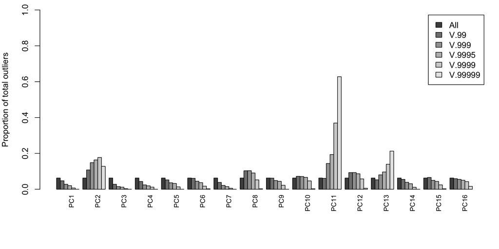

The PC axes that show enrichment are associated with growth variables. See the phenotypeSummary.html for more info.

#### Now loop through some these cutoffs and summarize the results for enrichment of different genomic categories:

There are two approaches toward looking at enrichment: based on annotation category, or based on the set of non-coding SNPs used in the covariance matrix.

##### Results based on annotation category

Here, for each locus I used the minimum p-value observed in any one environment. Then, I made a new annotation category that lumped together all non-synomymous SNPs. Next, I compared the proportion of SNPs in each annotation category for progressively more stringent cutoffs:

```r
  levels(f2$X_annotation)
```

```
##   [1] "3primeFLANK"     "3primeUTR"       "5primeFLANK"
##   [4] "5primeUTR"       "HAS_INDEL"       "intron"
##   [7] "mismatch_altref" "multi-allelic"   "non_tcontig"
##  [10] "nonsyn___to_C"   "nonsyn___to_E"   "nonsyn___to_G"
##  [13] "nonsyn___to_K"   "nonsyn___to_L"   "nonsyn___to_Q"
##  [16] "nonsyn___to_R"   "nonsyn___to_S"   "nonsyn___to_W"
##  [19] "nonsyn___to_Y"   "nonsyn_A_to_D"   "nonsyn_A_to_E"
##  [22] "nonsyn_A_to_G"   "nonsyn_A_to_P"   "nonsyn_A_to_S"
##  [25] "nonsyn_A_to_T"   "nonsyn_A_to_V"   "nonsyn_C_to__"
##  [28] "nonsyn_C_to_F"   "nonsyn_C_to_G"   "nonsyn_C_to_R"
##  [31] "nonsyn_C_to_S"   "nonsyn_C_to_W"   "nonsyn_C_to_Y"
##  [34] "nonsyn_D_to_A"   "nonsyn_D_to_E"   "nonsyn_D_to_G"
##  [37] "nonsyn_D_to_H"   "nonsyn_D_to_N"   "nonsyn_D_to_V"
##  [40] "nonsyn_D_to_Y"   "nonsyn_E_to__"   "nonsyn_E_to_A"
##  [43] "nonsyn_E_to_D"   "nonsyn_E_to_G"   "nonsyn_E_to_K"
```

[output cut: 46 more lines]

```r
### Make a new annotation category
    new.annot <- as.character(unlist(f2$X_annotation))
    new.annot[grep("nonsyn", f2$X_annotation)] <- "nonsyn"
    new.annot <- as.factor(new.annot)
    levels(new.annot)
```

```
##  [1] "3primeFLANK"     "3primeUTR"       "5primeFLANK"
##  [4] "5primeUTR"       "HAS_INDEL"       "intron"
##  [7] "mismatch_altref" "multi-allelic"   "non_tcontig"
## [10] "nonsyn"          "synonymous"      "unk_adj"
## [13] "unk_flank"       "UNKNOWN_ORF"
```

```
## [1] 15
## [1] 15
## [1] 15
## [1] 15
## [1] 15
```

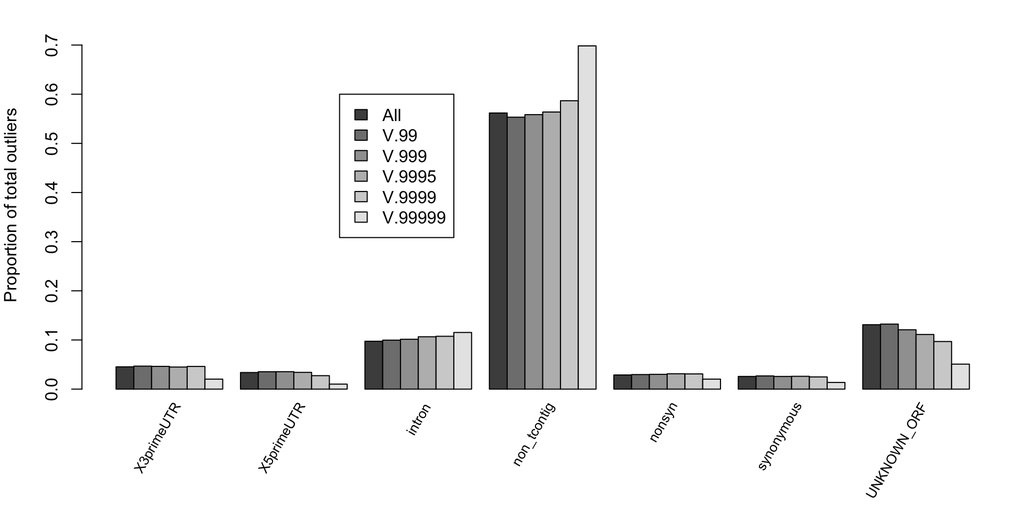

```r
### Calculate the max(BF) for a locus across all environments
  options(warn = -1)
  min.p <- apply(f2[,colBF], 1, min, na.rm=TRUE)
  min.p[is.infinite(min.p)]<-NA

### functions to get proportions
get.prop.newannot <- function(V, ind, rowname=NULL){
  a<- tapply(V[ind], new.annot[ind], length)
  a2<- data.frame(t(a/sum(a, na.rm=TRUE)))
  rownames(a2) <- rowname
  a2
  }

### For barplot, x-axis categories are in columns and colored bars are in rows
  enrich.new.annot <- data.frame(cutoff="All", get.prop.newannot(min.p, TRUE))

  cutoff2 <- as.numeric(cos[which.cutoffs[-1]])
  cutoff2names <- names(cos[which.cutoffs[-1]])
  for (i in 1:length(cutoff2)){
    n2 <- data.frame(cutoff=cutoff2names[i], get.prop.newannot(min.p, min.p<=cutoff2[i]) )
    print(length(n2))
    enrich.new.annot<- merge(enrich.new.annot, n2, all.x=TRUE, all.y=TRUE)
  }
```

The above results are SNP-based; they are probably driven by the significant outliers in the 5 growth days category.